# chapter 5、6

## question 5.1

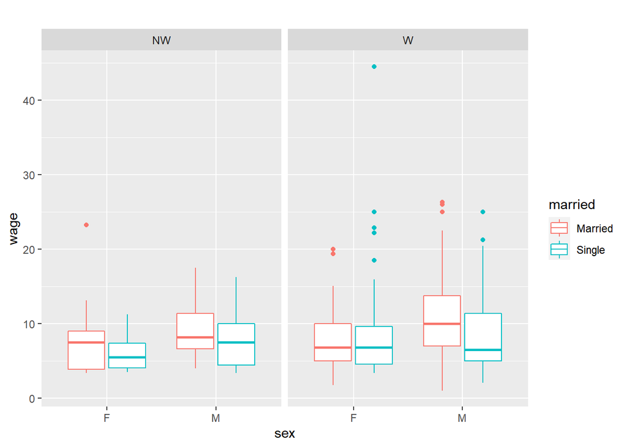

```r
rm(list = ls())

library(mosaicData)
library(mosaic)
library(tidyverse)
library(dcData)
data("CPS85")
ggplot(data = CPS85, aes(x = sex, y = wage)) +
  geom_boxplot()  +
  aes(colour = married) +
  facet_wrap(~race, ncol = 4) +
  theme(legend.position = "right") +
  labs(title = "")
```

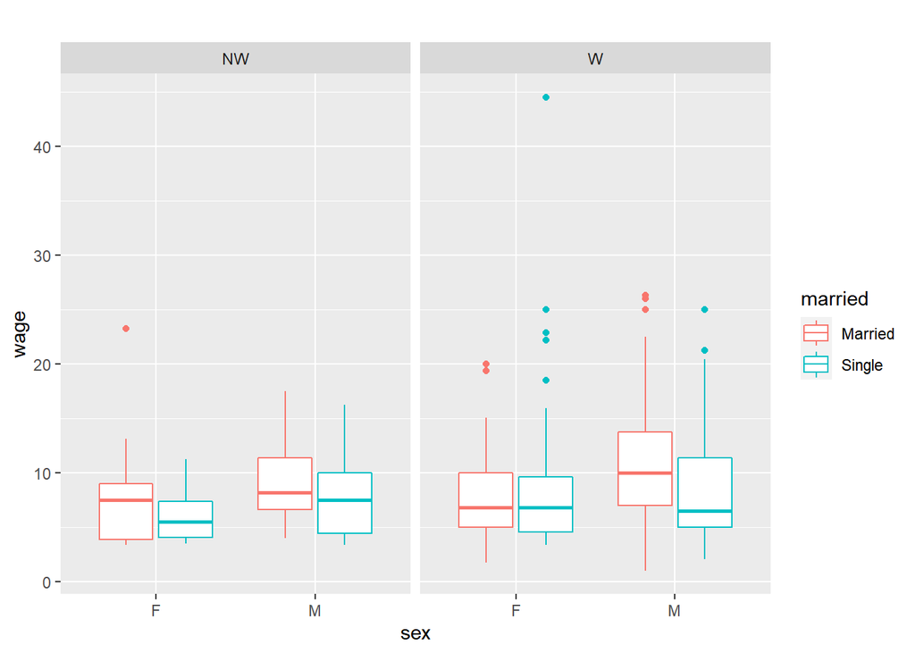

```r
CPS85 %>%
  ggplot(aes(x = sex, y = wage)) +
  geom_boxplot()  +
  aes(colour = married) +
  facet_wrap(~race, ncol = 4) +
  theme(legend.position = "right") +
  labs(title = "")
```

###question5.2

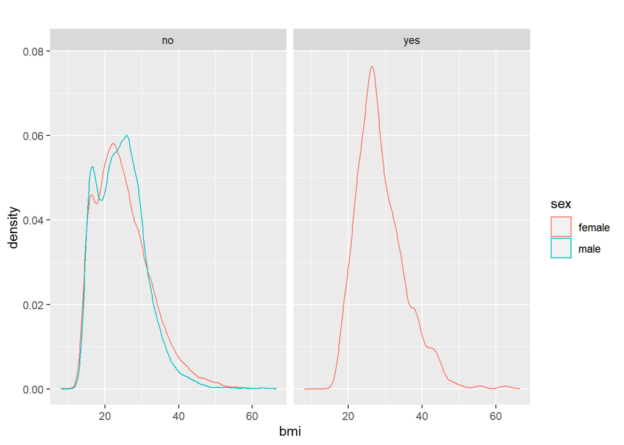

```r
data("NCHS")
ggplot( data = NCHS, aes(x = bmi)) +
  geom_density(adjust = 0.83) +
  aes(colour = sex) +
  facet_wrap(~pregnant, ncol = 4) +
  labs(title = "") +
  theme(legend.position = "right")
```

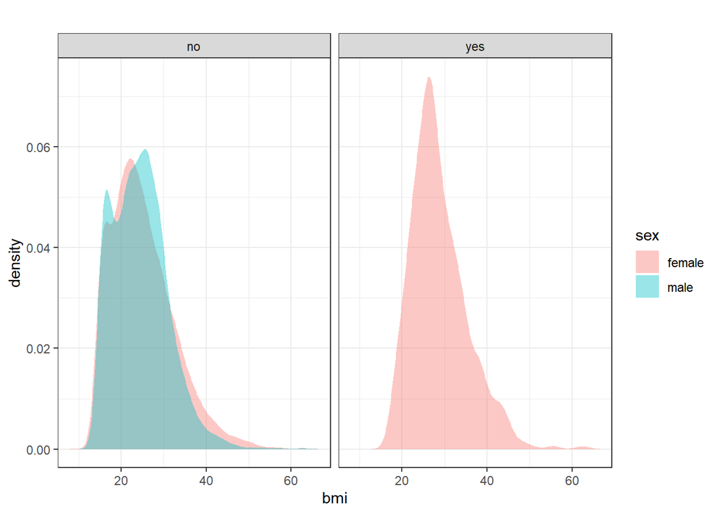

```r
ggplot(data = NCHS, aes(x = bmi)) +
  geom_density(adjust = 1, alpha = 0.4, color = NA) +
  aes(color = sex, fill = sex) +
  facet_wrap( ~ pregnant, ncol = 4) +
  labs(title = "") +
  theme(legend.position = "right") +
  theme_bw()
```

###question 5.3

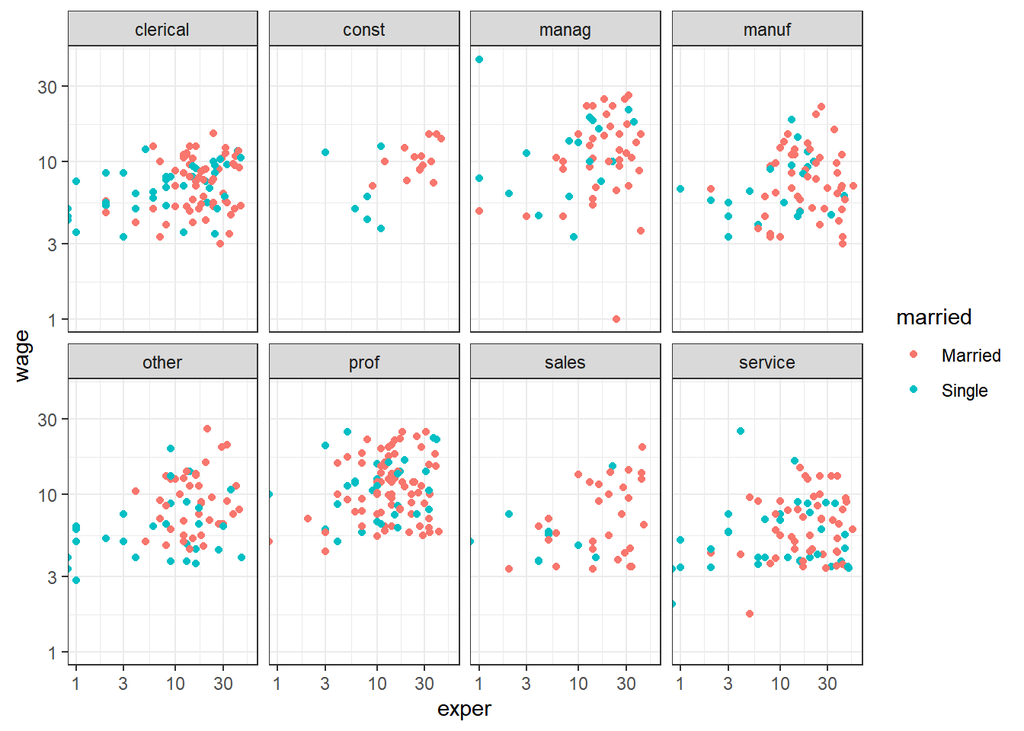

```r
ggplot(data = CPS85, aes(x = exper, y = wage)) +
  geom_point() +
  aes(colour = married) +
  facet_wrap( ~ sector, ncol = 4) +
  scale_x_log10() +
  scale_y_log10() +
  theme_bw()
```

chapter 6 ##6.1 “1433B”, “1433E”, “1433G”, “1433Z” Yes; all x-axes represent the different cell conditions and y-axes represent the amount of substance. *, vertical bars, red line segments

##6.2 Guides: y-axis tick marks, x-axis tick marks, color, fill, and sections of the x-axis concentration value corresponds to the y-position, genes correspond to x-position, molecules correspond to color, flux correspond to fill, target corresponds to placement on x-axis Graphical attributes: color, fill, location molecule corresponds to color, flux corresponds to fill, concentration, target, and gene correspond to location of the dot gene (x-axis) and concentration (y-axis) gene and target

##6.3 Glyph 1: vertical bar with labeled dot, corresponds to ‘protein’ and its low/center/high properties Glyph 2: stars, correspond to ‘signif’ Horizontal: defined by protein Vertical: defined by low/center/high Yes Guides: y-axis tick marks, glyph labels, blue label saying “polarity proteins”

##6.4 Rectangle defined by time of day and different transportation routes Solid lines, dashed lines, and dotted lines Shape/Style: Solid lines are time on public transport, dashed lines are time between transfers, dotted lines are (most likely) walking time Position: Time and route Time of day, total travel time, type of transportation

##6.5 State (vertical axis) and Polling Organization (horizontal axis).

##6.6 Glyph: Rectangle. Graphical attribute: color and text.

##6.7 NYT poll probability for the Democratic candidate

##6.8 Vertical scale: name of state. e: Color: color band

##6.9

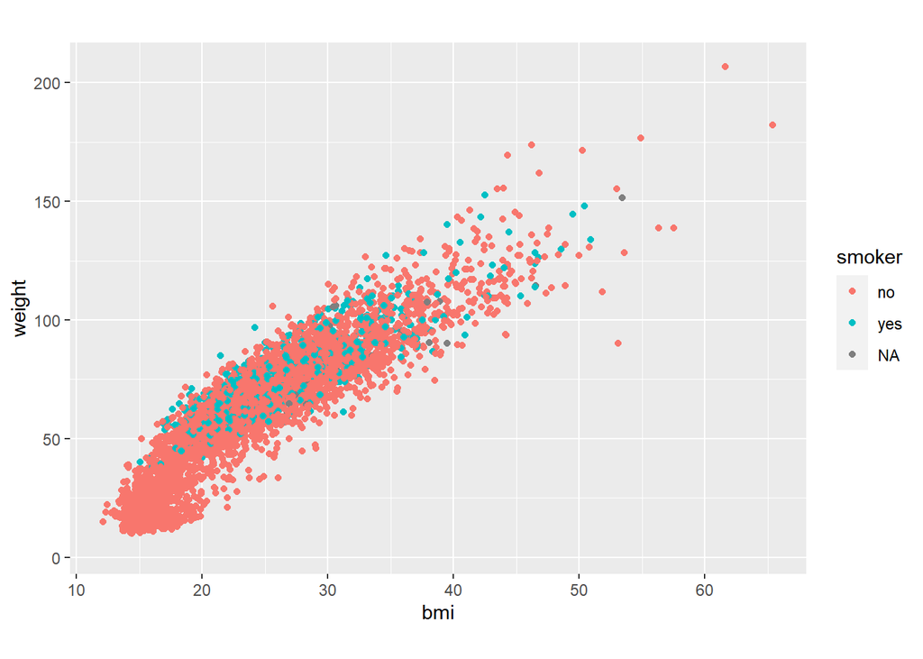

```r
Small <-
  NCHS %>%
  sample_n(size = 5000)
gf_point(weight ~ bmi, data = Small, color = ~ smoker) %>%
  gf_theme(legend.position = "right") %>%
  gf_labs(title = "", caption = "")
```

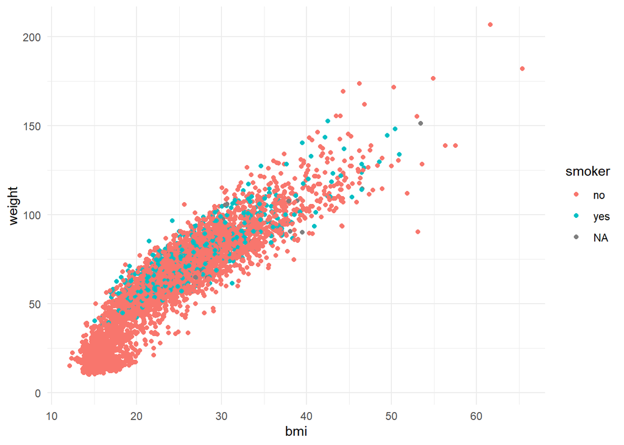

```r
ggplot(Small) +
  aes(x = bmi, y = weight, colour = smoker) +
  geom_point(shape = "circle", size = 1.5) +
  scale_color_hue(direction = 1) +
  theme_minimal()
```

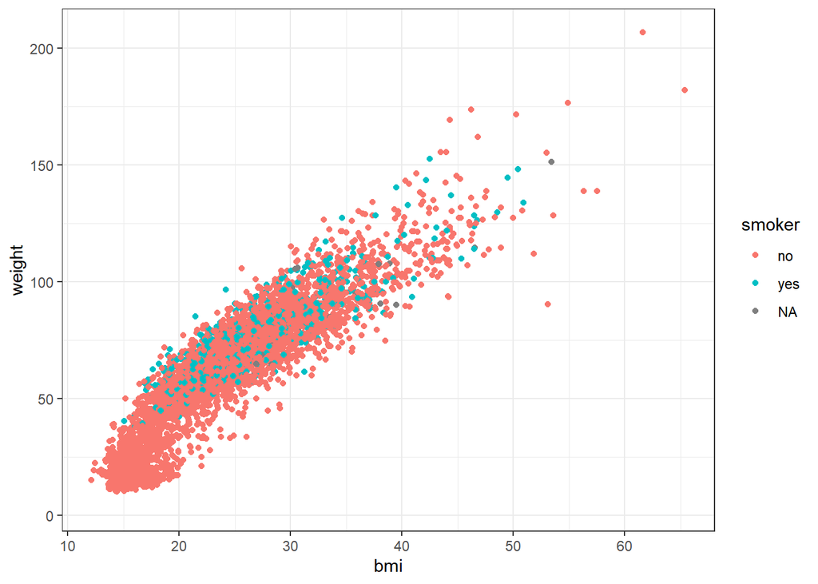

```r
Small %>%
  ggplot(aes(x = bmi, y = weight)) +
  geom_point() +
  aes(colour = smoker) +
  theme_bw()
```

##6.10 Inner layer: Classification tree structure Outer layer: Colored bands Inner scale: Division of space corresponding to the grouping of organisms Outer scale: Color corresponding to the type of molecule